# Fiche 1 : Introduction à R

## 2.4 Les graphes

On va passer très vite sur cette partie car la prochaine séance sera dédiée à l’utilisation du package **ggplot** qui permet de faire de bien plus jolis graphes que les fonctions de base de R. On donne juste ici la syntaxe pour faire un graphe avec la fonction **plot** :

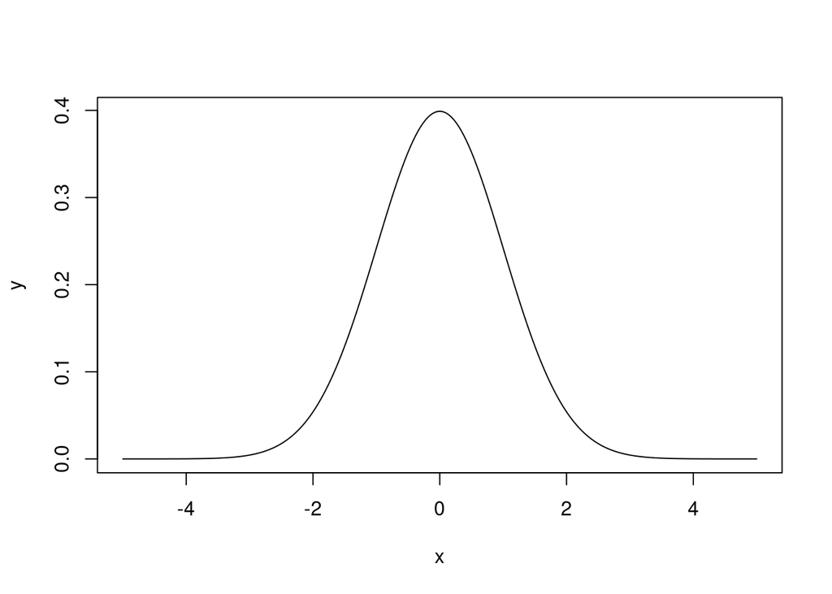

```r
x=seq(-5,5,0.01)
y=dnorm(x,0,1)
plot(x,y,"l")
```

Pour tracer une autre courbe sur le même graphe, on utilise la fonction **lines** :

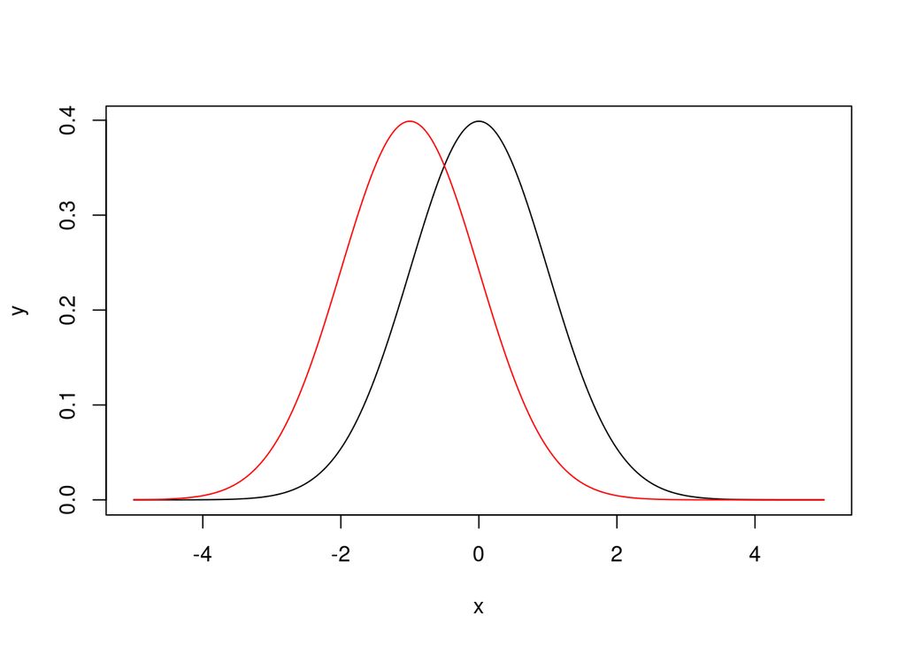

```r
x=seq(-5,5,0.01)
y=dnorm(x,0,1)
plot(x,y,"l")
y2=dnorm(x,-1,1)
lines(x,y2,col="red")
```

# 3. Exercices

On commencera par créer un dossier pour l’ensemble de ce cours, intitulé par exemple “Mise à Niveau R”. Il suffit alors, sous RStudio, d’aller dans `Session -> Set Working Directory -> Choose Directory` et de se placer dans le dossier “Mise à Niveau R”. Ensuite, aller dans `File -> New file -> Rmarkdown`. Ceci permet de créer un fichier Rmarkdown dans lequel vous pourrez faire les exercices suivants.

## 3.1. Sélection et tri dans un data-frame

Le jeu de données **iris** est disponible sous R. Il suffit de taper **data(iris)** pour le charger.

1. Obtenir un résumé de ce jeu de données grâce à la fonction **summary**. Quelles sont ses dimensions ?
2. Retrouver les dimensions de ce jeu de données grâce à la fonction **dim**.
3. Visualiser ses cinq premières lignes.
4. Créer un nouveau data-frame, que vous appellerez **iris2**, comportant uniquement les données de la modalité **versicolor** de la variable **Species**.
5. Trier par ordre croissant les données de **iris2** en fonction de la variable **Petal.Length** (vous pourrez utiliser la fonction **order**). Stocker le résultat dans un data-frame **iris3**. Vérifier le résultat sur les premières lignes de ce nouveau data-frame grâce à la fonction **head**.

## 3.2. Retrouver un nombre mystère

On étudie le nombre de tirages au hasard nécessaires pour retrouver un nombre fixé entre 0 et $n$.

1. Choisir un entier entre 0 et $n=10$, le stocker sous le nom **myst**. Ensuite, créer une boucle qui, à chaque itération, tire un entier au hasard entre 0 et $n=10$ jusqu’à obtenir **myst** (on pourra utiliser la fonction **sample** dont on consultera l’aide). En sortie de boucle, le nombre de tirages effectués sera renvoyé.
2. A partir de la question précédente, créer une fonction prenant en entrée les entiers $n$ et **myst**, et donnant en sortie le nombre de tirages nécessaires pour retrouver **myst**.
3. Pour $n=10$ et le même **myst** qu’en première question, appliquer cette fonction $M=100$ fois et stocker le résultat dans un vecteur **res**. Donner la moyenne de **res** et son écart-type. Quels sont les résultats attendus théoriquement ?
4. Si vous avez utilisé une boucle à la question précédente, la refaire en utilisant la fonction **apply**.

## 3.3. La conjecture de Syracuse

L’algorithme de Syracuse, ou algorithme $3x+1$, fonctionne comme suit : à partir d’un entier naturel $n\in\mathbb{N}^\star$, si $n$ est pair on le divise par deux, si $n$ est impair on le multiplie par 3 et on ajoute 1. On répète ensuite l’opération avec le nombre obtenu, la conjecture étant qu’on finit par atteindre 1 et boucler indéfiniment : en effet, à partir de ce nombre, on tombe sur le cycle 1,4,2.

1. Créer une fonction **syracuse** prenant un entier $n$ en entrée, générant cette suite de Syracuse et s’arrêtant lorsque l’on atteint 1. La fonction renverra en sortie la suite des nombres obtenus. Indication : on pourra utiliser la fonction **cbind** pour concaténer la suite obtenue au fur et à mesure de l’algorithme.
2. Grâce à une boucle, appliquer cette fonction à tous les entiers de 1 à 100 et stocker dans un vecteur les 100 longueurs des suites associées (on ne demande pas de stocker les 100 suites). A l’aide de la fonction **plot**, représenter sur un graphique les 100 longueurs.
3. Refaire la même chose sans utiliser de boucle, à l’aide de la fonction **sapply**. Comparer les temps de calcul. Même question avec $n=1000$.
4. Parmi les 100 suites créées, quelle est la longueur maximale atteinte ? Pour quel entier est-elle atteinte ? Pour celui-ci, représenter la suite de Syracuse associée.

## 3.4. Etude d’un jeu de données

Dans le cadre d’une étude de la population, un hôpital s’est intéressé à la propension à ronfler d’hommes et de femmes. Le fichier snore.txt contient un échantillon de 100 patients, les variables considérées sont :

- age : en années ;
- poids : en kg ;
- taille : en cm ;
- alcool : nombre de verres bus par jour (en équivalent verre de vin rouge) ;
- sexe : sexe de la personne (F=femme, H=homme) ;
- ronfle : diagnostic de ronflement (O=ronfle, N=ne ronfle pas) ;
- tabac : comportement au niveau du tabac (O=fumeur, N=non fumeur).

La première étape consiste à importer le jeu de données sous R. Pour ce faire, il faut au préalable vérifier que le fichier est enregistré dans le répertoire où R travaille. L’importation s’effectue alors à partir de la fonction **read.table** :

```r
donnees <- read.table("snore.txt")
```

1. Extraire le premier individu du jeu de données. Que remarquez-vous ?
2. A partir de l’aide de la fonction **read.table**, résoudre ce problème.
3. Analyser les sorties de la commande :

```r
summary(donnees)
```

4. Créer deux tableaux de données issus du tableau original : un tableau nommé **ronfleur** qui contient uniquement les individus qui ronflent et un autre nommé **nonronfleur** qui contient les individus ne ronflant pas (on pourra utiliser la fonction **split**).
5. Résumer les deux tableaux de données. Comparer ces indicateurs, interpréter.
6. Quelle est la proportion d’hommes parmi les personnes qui ronflent ? Quelle est la proportion de ronfleurs parmi les hommes ?

## 3.5 Pour aller plus loin : Chaîne de Markov

On définit pour tout $n \in \mathbb{N}$ une chaîne de Markov $X_n$ homogène sur $E=\{1,2,3\}$, i.e. pour tout couple $(i,j) \in E^2$,
$$P(X_{n+1}=j \vert X_n=i)=P_{i,j},$$
avec $P$ définie par

$$P=\begin{pmatrix} 1/3 & 1/3& 1/3
\\
0 & 1/2 & 1/2 \\
1/2 & 1/2 & 0
\end{pmatrix}.$$
La matrice $P$ est appelée matrice de transition. Chaque entrée $P_{i,j}$ représente la probabilité de passer d’un état $i$ à un état $j$ (on remarque d’ailleurs que la somme de chaque ligne vaut 1). On initialise la chaîne à l’état 1, i.e $X_0=1$.

1. Coder une fonction qui permet de simuler une trajectoire de taille 50 (i.e une fonction qui renvoie les états $X_1, \dots, X_{50}$).
2. Simuler 3 trajectoires et les représenter sur le même graphique.
3. Simuler une trajectoire de taille $1000$ et représenter sur un même graphique les fonctions
   $$T\mapsto \frac{1}{T}
   \sum_{n=1}^T \mathbb{1}_{\{X_n=1\}} \ , \quad
   T\mapsto \frac{1}{T} \sum_{n=1}^T \mathbb{1}_{\{X_n=2\}} \quad \mbox{et}
   \quad
   T\mapsto \frac{1}{T} \sum_{n=1}^T\mathbb{1}_{\{X_n=3\}}$$
   pour $T=1,\dots,1000$. Que remarque-t-on ? Ceci est une illustration d’un résultat fondamental sur les chaînes de Markov, qu’on appelle le théorème ergodique.